# Final Project DTSA 5510

### Customer Clustering

Using simulated data, I plan to use K-means and agglomerative clustering to create groups of customers. This clustering could in turn be used for targeting ads or timing sales for specific populations to maximize profits.

```python
import numpy as np
import pandas as pd

from sklearn.decomposition import NMF
from sklearn.model_selection import train_test_split
from sklearn.decomposition import NMF
from sklearn.linear_model import LogisticRegression
from sklearn.metrics import make_scorer, accuracy_score
from sklearn.model_selection import GridSearchCV
from sklearn.metrics import confusion_matrix
from sklearn.metrics import ConfusionMatrixDisplay
from sklearn.feature_extraction.text import TfidfVectorizer
from sklearn.cluster import KMeans
from sklearn.metrics import silhouette_score
import matplotlib.pyplot as plt
import seaborn as sns
from sklearn.decomposition import PCA
from sklearn import metrics
from sklearn.cluster import DBSCAN
from sklearn.cluster import AgglomerativeClustering

from sklearn.preprocessing import StandardScaler, normalize
import scipy.cluster.hierarchy as shc
```

## The data

The dataset that I am using can be downloaded from https://www.kaggle.com/datasets/rodsaldanha/arketing-campaign/data. It was created by Rodolfo Saldanha.

I will be cleaning the data by removing all rows with null values. I will also be removing any unneeded columns.

```python
file_loc = 'customer_data/marketing_campaign.csv'

df = pd.read_csv(file_loc)
```

```python
df.head()
```

|  | ID | Year_Birth | Education | Marital_Status | Income | Kidhome | Teenhome | Dt_Customer | Recency | MntWines | ... | NumWebVisitsMonth | AcceptedCmp3 | AcceptedCmp4 | AcceptedCmp5 | AcceptedCmp1 | AcceptedCmp2 | Complain | Z_CostContact | Z_Revenue | Response |
| --- | --- | --- | --- | --- | --- | --- | --- | --- | --- | --- | --- | --- | --- | --- | --- | --- | --- | --- | --- | --- | --- |
| 0 | 5524 | 1957 | Graduation | Single | 58138.0 | 0 | 0 | 9/4/12 | 58 | 635 | ... | 7 | 0 | 0 | 0 | 0 | 0 | 0 | 3 | 11 | 1 |
| 1 | 2174 | 1954 | Graduation | Single | 46344.0 | 1 | 1 | 3/8/14 | 38 | 11 | ... | 5 | 0 | 0 | 0 | 0 | 0 | 0 | 3 | 11 | 0 |
| 2 | 4141 | 1965 | Graduation | Together | 71613.0 | 0 | 0 | 8/21/13 | 26 | 426 | ... | 4 | 0 | 0 | 0 | 0 | 0 | 0 | 3 | 11 | 0 |
| 3 | 6182 | 1984 | Graduation | Together | 26646.0 | 1 | 0 | 2/10/14 | 26 | 11 | ... | 6 | 0 | 0 | 0 | 0 | 0 | 0 | 3 | 11 | 0 |
| 4 | 5324 | 1981 | PhD | Married | 58293.0 | 1 | 0 | 1/19/14 | 94 | 173 | ... | 5 | 0 | 0 | 0 | 0 | 0 | 0 | 3 | 11 | 0 |

5 rows × 29 columns

Identifying all non-numeric columns. Will either delete the column or encode before creating the models.

```python
non_numeric = (df.dtypes == 'object')
object_cols = list(non_numeric[non_numeric].index)
object_cols
```

```
['Education', 'Marital_Status', 'Dt_Customer']
```

```python
print(df['Marital_Status'].unique())
print(df['Education'].unique())
```

```
['Single' 'Together' 'Married' 'Divorced' 'Widow' 'Alone' 'Absurd' 'YOLO']
['Graduation' 'PhD' 'Master' 'Basic' '2n Cycle']
```

```python
df.loc[df["Education"] == "Graduation", "Education"] = 12
df.loc[df["Education"] == "PhD", "Education"] = 17
df.loc[df["Education"] == "Master", "Education"] = 15
df.loc[df["Education"] == "Basic", "Education"] = 9
df.loc[df["Education"] == "2n Cycle", "Education"] = 14

df.loc[(df["Marital_Status"] == "Married") | (df["Marital_Status"] == "Together"), "Marital_Status"] = 1
df.loc[(df["Marital_Status"] != "Married") & (df["Marital_Status"] != "Together"), "Marital_Status"] = 0
```

```python
df.info()
```

```
<class 'pandas.core.frame.DataFrame'>
RangeIndex: 2240 entries, 0 to 2239
Data columns (total 29 columns):
 #   Column               Non-Null Count  Dtype
---  ------               --------------  -----
 0   ID                   2240 non-null   int64
 1   Year_Birth           2240 non-null   int64
 2   Education            2240 non-null   object
 3   Marital_Status       2240 non-null   object
 4   Income               2216 non-null   float64
 5   Kidhome              2240 non-null   int64
 6   Teenhome             2240 non-null   int64
 7   Dt_Customer          2240 non-null   object
 8   Recency              2240 non-null   int64
 9   MntWines             2240 non-null   int64
```

[output cut: 21 more lines]

There are na values in the income column, so we will remove all rows that do not have an income value.

```python
df.dropna(axis=0, inplace=True)
```

Now I will create a few new columns.

Childreninhousehold will combine Kidhome and Teenhome to get the total number of children in the home.

Parent will be a boolean 1 if the individual has kids or 0 if not.

Age will replace Year_Birth.

```python
df['Childreninhousehold'] = df['Kidhome'] + df['Teenhome']

df['Parent'] = np.where(df.Childreninhousehold> 0, 1, 0)

df['Age'] = 2024 - df['Year_Birth']
df['Total_spent'] = df['MntWines'] + df['MntFruits'] + df['MntMeatProducts'] + df['MntFishProducts'] + df['MntGoldProds']
```

```python
df.columns
```

```
Index(['ID', 'Year_Birth', 'Education', 'Marital_Status', 'Income', 'Kidhome',
       'Teenhome', 'Dt_Customer', 'Recency', 'MntWines', 'MntFruits',
       'MntMeatProducts', 'MntFishProducts', 'MntSweetProducts',
       'MntGoldProds', 'NumDealsPurchases', 'NumWebPurchases',
       'NumCatalogPurchases', 'NumStorePurchases', 'NumWebVisitsMonth',
       'AcceptedCmp3', 'AcceptedCmp4', 'AcceptedCmp5', 'AcceptedCmp1',
       'AcceptedCmp2', 'Complain', 'Z_CostContact', 'Z_Revenue', 'Response',
       'Childreninhousehold', 'Parent', 'Age', 'Total_spent'],
      dtype='object')
```

Removing un-needed columns

```python
cols_to_del = ['Dt_Customer', 'Year_Birth', 'ID', 'AcceptedCmp3', 'AcceptedCmp4', 'AcceptedCmp5', 'AcceptedCmp1', 'AcceptedCmp2']

df.drop(cols_to_del, axis=1, inplace=True)
```

Now I will plot the data to look for outliers which I will remove from the dataset

[figure not shown]

```python
plt.scatter(df['Age'], df['Income']);
plt.xlabel("Age")
plt.ylabel("Income")

plt.show()
```

```python
df = df[df['Age'] < 100]
df = df[df['Income'] < 500000]
```

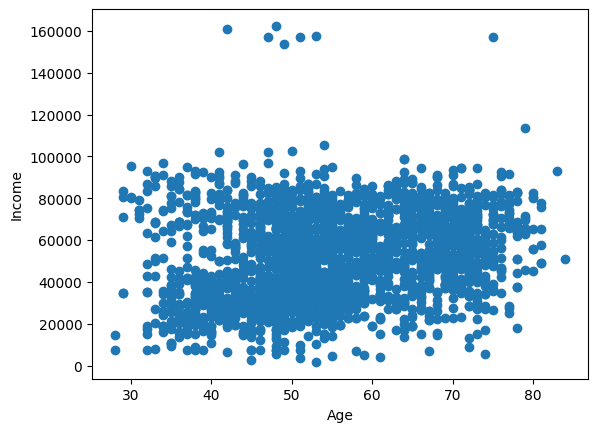

```python
plt.scatter(df['Age'], df['Income']);
plt.xlabel("Age")
plt.ylabel("Income")
plt.show()
```

## Modeling the Data

First I will model the data using K-means clustering. Using the elbow method to find the optimal value for k

```python
scaler = StandardScaler()
scaler.fit(df)
scaled_df = pd.DataFrame(scaler.transform(df),columns= df.columns )

scaled_df.dropna(inplace=True)
```

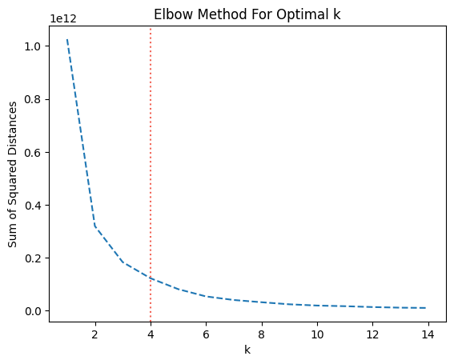

```python
Sum_of_squared_distances = []
K = range(1,15)
for k in K:
    km = KMeans(init="k-means++", n_clusters=k)
    km = km.fit(df)
    Sum_of_squared_distances.append(km.inertia_)

ax = sns.lineplot(x=K, y=Sum_of_squared_distances)
ax.lines[0].set_linestyle("--")

# Add a vertical line to show the optimum number of clusters
plt.axvline(4, color='#F26457', linestyle=':')

plt.xlabel('k')
plt.ylabel('Sum of Squared Distances')
plt.title('Elbow Method For Optimal k')
plt.show()
```

```python
pca = PCA(4)
transformed_df = pca.fit_transform(scaled_df)
k = 4
km = KMeans(init="k-means++", n_clusters=k, max_iter=100, n_init=1)
labels = km.fit_predict(transformed_df)
print(labels)
```

```
[1 3 1 ... 1 2 3]
```

```python
scaled_df["cluster"] = km.labels_
```

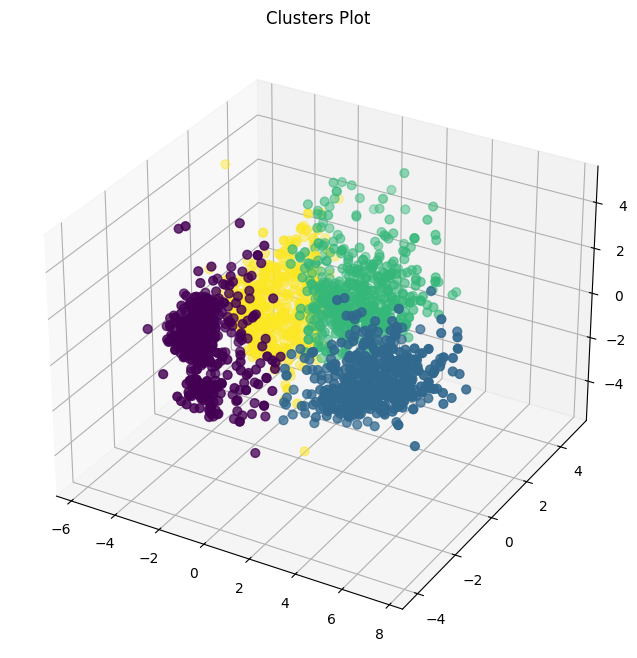

```python
pca_num_components = 4

pca = PCA(n_components=pca_num_components)

reduced_data = pca.fit_transform(scaled_df)
results = pd.DataFrame(reduced_data,columns=['pca1','pca2', 'pca3', 'pca4'])

x =results['pca1']
y =results['pca2']
z =results['pca3']

fig = plt.figure(figsize=(8,8))
ax = plt.subplot(111, projection='3d', label="bla")
ax.scatter(x, y, z, s=40, c=scaled_df["cluster"], marker='o')
ax.set_title("Clusters Plot")
plt.show()
```

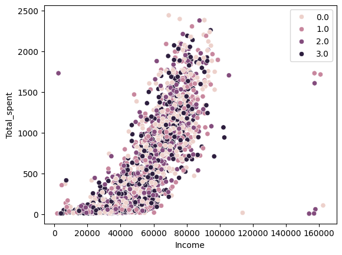

```python
income_plot = sns.scatterplot(data = df,x=df["Income"], y=df["Total_spent"],hue=scaled_df["cluster"])
plt.legend()
plt.show()
```

Hard to see any distinct groups based on the income vs. spending plot. So let's look at a few more plots.

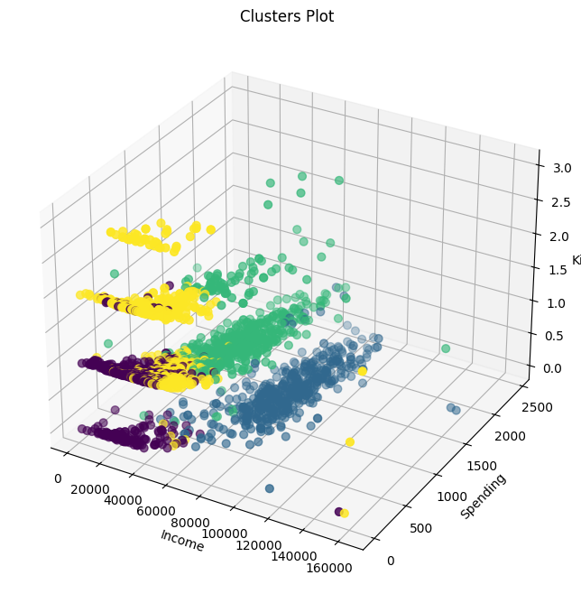

```python
x =df['Income']
y =df['Total_spent']
z =df['Childreninhousehold']

fig = plt.figure(figsize=(10,8))
ax = plt.subplot(111, projection='3d', label="bla")
ax.scatter(x, y, z, s=40, c=scaled_df["cluster"], marker='o')
ax.set_title("Clusters Plot")
ax.set_xlabel('Income')
ax.set_ylabel('Spending')
ax.set_zlabel('Kids')

plt.show()
```

Clear distinctions between the groups when we look at the 3d plot.

Purple: Low income, low spenders, 0-1 kids

Blue: High income, high spenders, no kids

```python
label0 = df[labels == 0]
label1 = df[labels == 1]
label2 = df[labels == 2]
label3 = df[labels == 3]
```

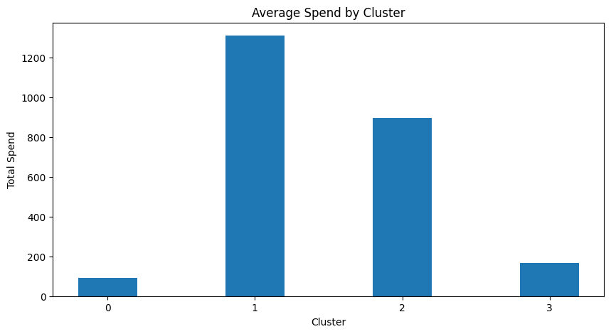

```python
mean_spend = {'0':label0['Total_spent'].mean(), '1':label1['Total_spent'].mean(), '2':label2['Total_spent'].mean(),
        '3':label3['Total_spent'].mean()}
fig = plt.figure(figsize = (10, 5))

spends = list(mean_spend.keys())
values = list(mean_spend.values())

# creating the bar plot
plt.bar(spends, values,
        width = 0.4)

plt.xlabel("Cluster")
plt.ylabel("Total Spend")
plt.title("Average Spend by Cluster")
plt.show()
```

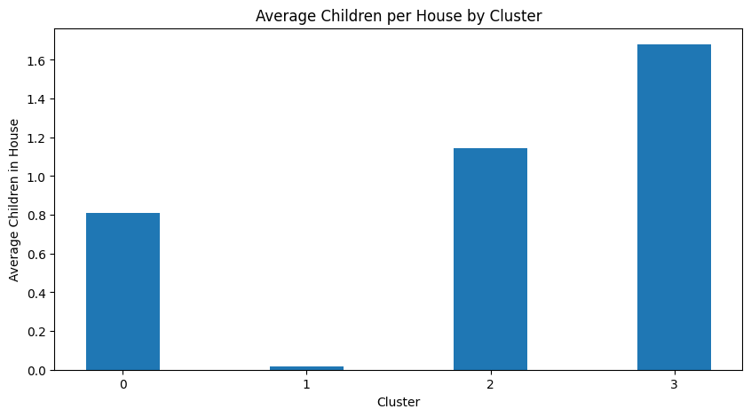

```python
mean_kids = {'0':label0['Childreninhousehold'].mean(), '1':label1['Childreninhousehold'].mean(), '2':label2['Childreninhousehold'].mean(),
        '3':label3['Childreninhousehold'].mean()}
fig = plt.figure(figsize = (10, 5))

clust = list(mean_kids.keys())
values = list(mean_kids.values())

# creating the bar plot
plt.bar(clust, values,
        width = 0.4)

plt.xlabel("Cluster")
plt.ylabel("Average Children in House")
plt.title("Average Children per House by Cluster")
plt.show()
```

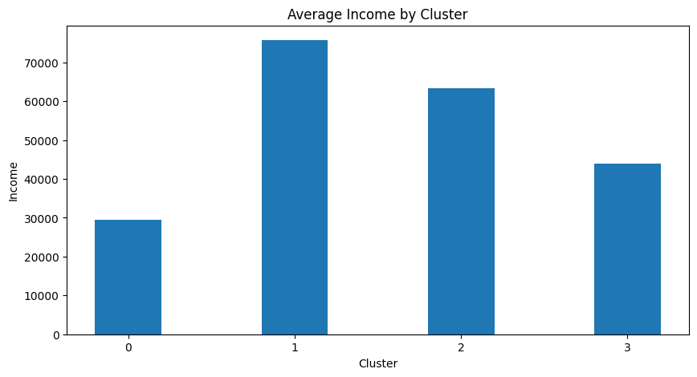

```python
mean_income = {'0':label0['Income'].mean(), '1':label1['Income'].mean(), '2':label2['Income'].mean(),
        '3':label3['Income'].mean()}
fig = plt.figure(figsize = (10, 5))

clust = list(mean_income.keys())
values = list(mean_income.values())

# creating the bar plot
plt.bar(clust, values,
        width = 0.4)

plt.xlabel("Cluster")
plt.ylabel("Income")
plt.title("Average Income by Cluster")
plt.show()
```

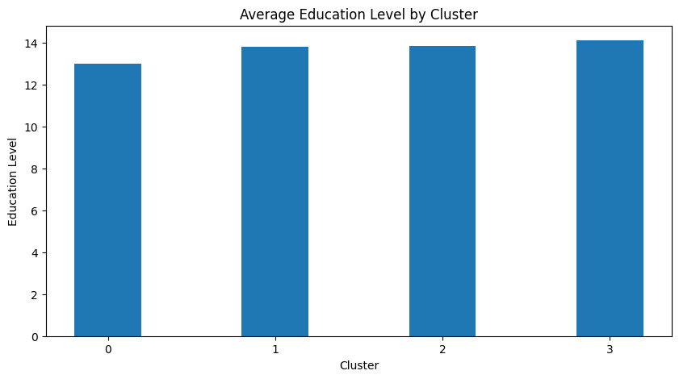

```python
mean_ed = {'0':label0['Education'].mean(), '1':label1['Education'].mean(), '2':label2['Education'].mean(),
        '3':label3['Education'].mean()}
fig = plt.figure(figsize = (10, 5))

clust = list(mean_ed.keys())
values = list(mean_ed.values())

# creating the bar plot
plt.bar(clust, values,
        width = 0.4)

plt.xlabel("Cluster")
plt.ylabel("Education Level")
plt.title("Average Education Level by Cluster")
plt.show()
```

### Testing another model: Agglomerative Clustering

```python
#normalize the data before modeling
df_normalized = normalize(scaled_df)
df_normalized = pd.DataFrame(df_normalized)
```

```python
pca = PCA(n_components = 2)
X_principal = pca.fit_transform(df_normalized)
X_principal = pd.DataFrame(X_principal)
X_principal.columns = ['P1', 'P2']
```

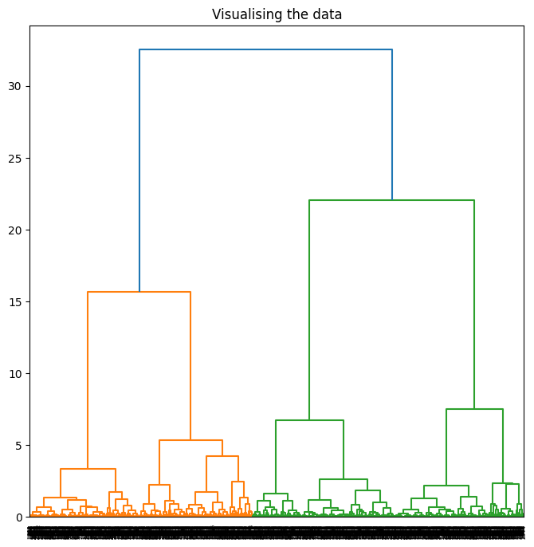

```python
plt.figure(figsize =(8, 8))
plt.title('Visualising the data')
Dendrogram = shc.dendrogram((shc.linkage(X_principal, method ='ward')))
```

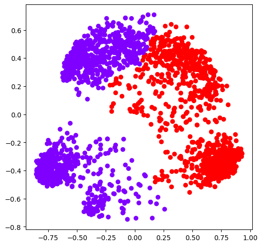

```python
ac2 = AgglomerativeClustering(n_clusters = 2)

# Visualizing the clustering
plt.figure(figsize =(6, 6))
plt.scatter(X_principal['P1'], X_principal['P2'],
           c = ac2.fit_predict(X_principal), cmap ='rainbow')
plt.show()
```

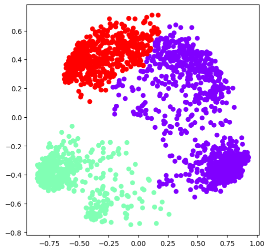

```python
ac3 = AgglomerativeClustering(n_clusters = 3)

plt.figure(figsize =(6, 6))
plt.scatter(X_principal['P1'], X_principal['P2'],
           c = ac3.fit_predict(X_principal), cmap ='rainbow')
plt.show()
```

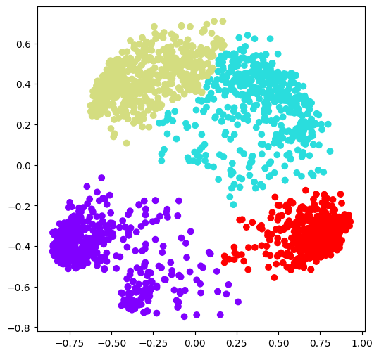

```python
ac4 = AgglomerativeClustering(n_clusters = 4)

plt.figure(figsize =(6, 6))
plt.scatter(X_principal['P1'], X_principal['P2'],
            c = ac4.fit_predict(X_principal), cmap ='rainbow')
plt.show()
```

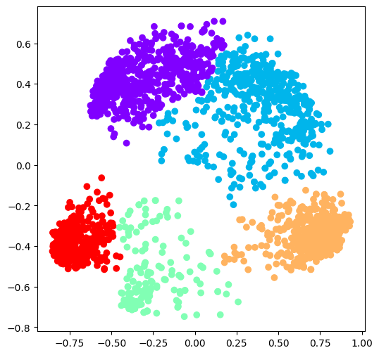

```python
ac5 = AgglomerativeClustering(n_clusters = 5)

plt.figure(figsize =(6, 6))
plt.scatter(X_principal['P1'], X_principal['P2'],
            c = ac5.fit_predict(X_principal), cmap ='rainbow')
plt.show()
```

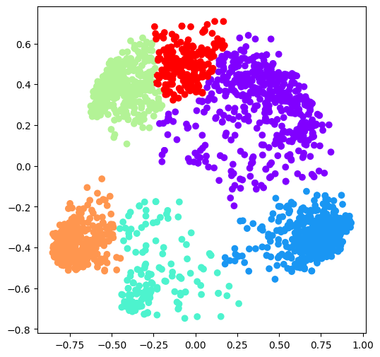

```python
ac6 = AgglomerativeClustering(n_clusters = 6)

plt.figure(figsize =(6, 6))
plt.scatter(X_principal['P1'], X_principal['P2'],
            c = ac6.fit_predict(X_principal), cmap ='rainbow')
plt.show()
```

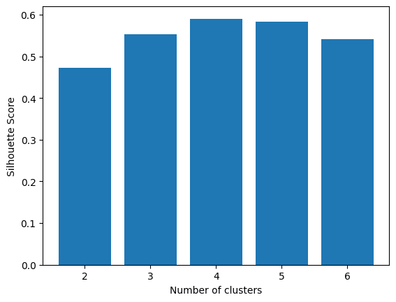

```python
k = [2, 3, 4, 5, 6]

# Appending the silhouette scores of the different models to the list
silhouette_scores = []
silhouette_scores.append(
        silhouette_score(X_principal, ac2.fit_predict(X_principal)))
silhouette_scores.append(
        silhouette_score(X_principal, ac3.fit_predict(X_principal)))
silhouette_scores.append(
        silhouette_score(X_principal, ac4.fit_predict(X_principal)))
silhouette_scores.append(
        silhouette_score(X_principal, ac5.fit_predict(X_principal)))
silhouette_scores.append(
        silhouette_score(X_principal, ac6.fit_predict(X_principal)))

# Plotting a bar graph to compare the results
plt.bar(k, silhouette_scores)
plt.xlabel('Number of clusters')
plt.ylabel('Silhouette Score')
plt.show()
```

Based on the silouhette scores, the optimal number of clusters is 4.

```python
#using ac2
# fit model and predict clusters
yhat_ac = ac4.fit_predict(df)
df["AG Clusters"] = yhat_ac
```

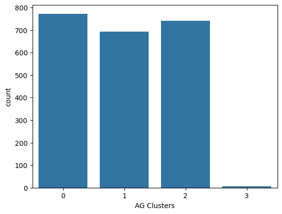

```python
pl = sns.countplot(x=df["AG Clusters"])
plt.show()
```

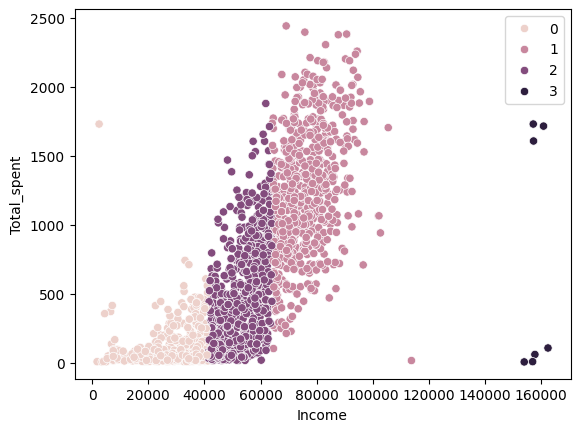

```python
income_plot = sns.scatterplot(data = df,x=df["Income"], y=df["Total_spent"],hue=df["AG Clusters"])
a, b = np.polyfit(x, y, 1)
plt.legend()
plt.show()
```

Looking at the above plot, we can see that the clusters are clearly divided along income lines.

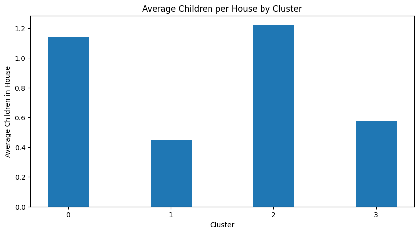

```python
ag0_df = df[df['AG Clusters'] == 0]
ag1_df = df[df['AG Clusters'] == 1]
ag2_df = df[df['AG Clusters'] == 2]
ag3_df = df[df['AG Clusters'] == 3]

mean_kids = {'0':ag0_df['Childreninhousehold'].mean(), '1':ag1_df['Childreninhousehold'].mean(),
             '2':ag2_df['Childreninhousehold'].mean(), '3':ag3_df['Childreninhousehold'].mean()}
fig = plt.figure(figsize = (10, 5))

clust = list(mean_kids.keys())
values = list(mean_kids.values())

plt.bar(clust, values,
        width = 0.4)

plt.xlabel("Cluster")
plt.ylabel("Average Children in House")
plt.title("Average Children per House by Cluster")
plt.show()
```